# clean code

## Important note

After analyzing the distribution of both `x` & `y` we notice a major `similarity` between them, let's discover this `statistically`.

```python
# values of 30 last values
data[['x','y']].tail(30)
```

|  | x | y |
| --- | --- | --- |
| 53763 | 5.63 | 5.67 |
| 53764 | 5.74 | 5.77 |
| 53765 | 5.43 | 5.38 |
| 53766 | 5.48 | 5.40 |
| 53767 | 5.84 | 5.81 |
| 53768 | 5.94 | 5.90 |
| 53769 | 5.84 | 5.86 |
| 53770 | 5.71 | 5.74 |
| 53771 | 6.12 | 6.09 |
| 53772 | 5.93 | 5.85 |
| 53773 | 5.89 | 5.87 |
| 53774 | 5.57 | 5.61 |
| 53775 | 5.59 | 5.65 |
| 53776 | 5.67 | 5.58 |
| 53777 | 5.80 | 5.84 |
| 53778 | 5.82 | 5.84 |
| 53779 | 5.95 | 5.97 |
| 53780 | 5.71 | 5.73 |
| 53782 | 6.03 | 5.96 |
| 53783 | 5.76 | 5.73 |
| 53784 | 5.79 | 5.74 |
| 53785 | 5.74 | 5.73 |
| 53786 | 5.71 | 5.76 |
| 53787 | 5.69 | 5.72 |
| 53788 | 5.69 | 5.73 |
| 53789 | 5.75 | 5.76 |
| 53790 | 5.69 | 5.75 |
| 53791 | 5.66 | 5.68 |
| 53792 | 6.15 | 6.12 |
| 53793 | 5.83 | 5.87 |

```python
# statistics about x and y
data[['x','y']].describe().T
```

|  | count | mean | std | min | 25% | 50% | 75% | max |
| --- | --- | --- | --- | --- | --- | --- | --- | --- |
| x | 49191.0 | 5.616158 | 1.027540 | 3.73 | 4.67 | 5.61 | 6.47 | 8.34 |
| y | 49191.0 | 5.620879 | 1.021784 | 3.68 | 4.68 | 5.61 | 6.47 | 8.27 |

```
array([[<AxesSubplot:title={'center':'x'}>,
        <AxesSubplot:title={'center':'y'}>]], dtype=object)
```

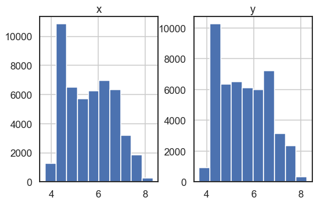

```python
# distribution of x and y
data[['x','y']].hist(figsize=(8,5))
```

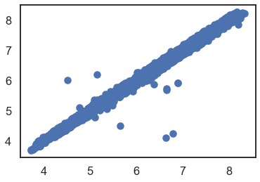

```python
# scatter plot of x and y
plt.scatter(data['x'],data['y'])
```

- So, our hypothesis is true

```python
# let's examine the ratio
(data['x']/data['y']).describe().to_frame().T
```

|  | count | mean | std | min | 25% | 50% | 75% | max |
| --- | --- | --- | --- | --- | --- | --- | --- | --- |
| 0 | 49191.0 | 0.998996 | 0.009738 | 0.749169 | 0.9925 | 0.995495 | 1.006766 | 1.615572 |

This suggests removing one of the two features as no additional information is given(when one of them is here we can easily infer the second)

```python
# drop the `x` variable
data = data.drop('x',axis=1)
```

```python
# preview
data.head()
```

|  | carat | cut | color | clarity | depth | table | price | y | z | log(y) |
| --- | --- | --- | --- | --- | --- | --- | --- | --- | --- | --- |
| 0 | 0.23 | 4.0 | 5.0 | 1.0 | 61.5 | 55.0 | 326 | 3.98 | 2.43 | 1.605430 |
| 1 | 0.21 | 3.0 | 5.0 | 2.0 | 59.8 | 61.0 | 326 | 3.84 | 2.31 | 1.576915 |
| 3 | 0.29 | 3.0 | 1.0 | 3.0 | 62.4 | 58.0 | 334 | 4.23 | 2.63 | 1.654411 |
| 4 | 0.31 | 1.0 | 0.0 | 1.0 | 63.3 | 58.0 | 335 | 4.35 | 2.75 | 1.677097 |
| 5 | 0.24 | 2.0 | 0.0 | 5.0 | 62.8 | 57.0 | 336 | 3.96 | 2.48 | 1.601406 |

```python
# save the New data for future
data.to_csv('clean_data.csv',index=False)
```

----------------------Execute from here------------------------------------

```python
# import data
    # libraries
import pandas as pd
import numpy as np
import matplotlib.pyplot as plt
import seaborn as sns
    # set seaborn as default style
sns.set()
data = pd.read_csv('clean_data.csv')
```

### Features` skewness

```python
data.skew()
```

```
carat      0.729621
cut       -0.641315
color     -0.213516
clarity    0.526213
depth     -0.245751
table      0.377942
price      1.597436
y          0.256599
z          0.254492
log(y)     0.073074
dtype: float64
```

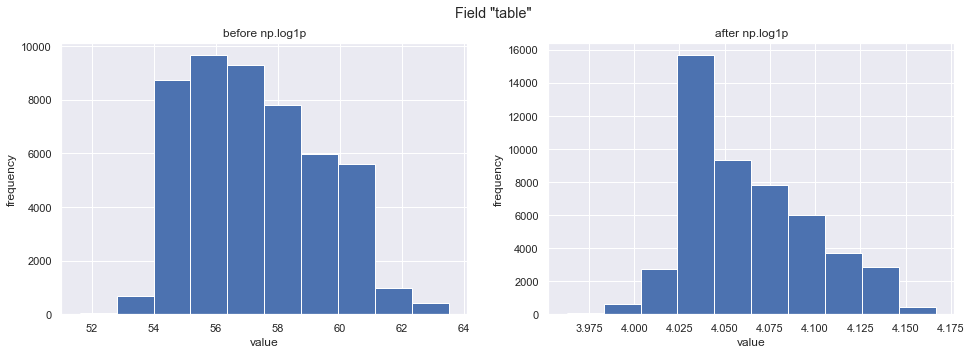

```python
# # Let's look at what happens to one of these features, when we apply np.log1p visually.

# Choose a field
field = "table"

# Create two "subplots" and a "figure" using matplotlib
fig, (ax_before, ax_after) = plt.subplots(1, 2, figsize=(16, 5))

# Create a histogram on the "ax_before" subplot
data[field].hist(ax=ax_before)

# Apply a log transformation (numpy syntax) to this column
data[field].apply(np.log1p).hist(ax=ax_after)

# Formatting of titles etc. for each subplot
ax_before.set(title='before np.log1p', ylabel='frequency', xlabel='value')
ax_after.set(title='after np.log1p', ylabel='frequency', xlabel='value')
fig.suptitle('Field "{}"'.format(field));
```

- During our model-building process, we'll create a pipeline containing `standarization` to ensure that all features have the `same scale`

-------------------------------------------------------------------example----------------------------------------------------------------

For example, A variable that ranges between 0 and 1000 will `outweigh` a variable that ranges between 0 and 1. Using these variables without standardization will give the variable with the larger range weight of 1000 in the analysis. Transforming the data to comparable scales can prevent this problem. Typical `data standardization` procedures `equalize` the range and/or data variability.

### Building our ML model

```python
# review data
data.head()
```

|  | carat | cut | color | clarity | depth | table | price | y | z | log(y) |
| --- | --- | --- | --- | --- | --- | --- | --- | --- | --- | --- |
| 0 | 0.23 | 4.0 | 5.0 | 1.0 | 61.5 | 55.0 | 326 | 3.98 | 2.43 | 1.605430 |
| 1 | 0.21 | 3.0 | 5.0 | 2.0 | 59.8 | 61.0 | 326 | 3.84 | 2.31 | 1.576915 |
| 2 | 0.29 | 3.0 | 1.0 | 3.0 | 62.4 | 58.0 | 334 | 4.23 | 2.63 | 1.654411 |
| 3 | 0.31 | 1.0 | 0.0 | 1.0 | 63.3 | 58.0 | 335 | 4.35 | 2.75 | 1.677097 |
| 4 | 0.24 | 2.0 | 0.0 | 5.0 | 62.8 | 57.0 | 336 | 3.96 | 2.48 | 1.601406 |

```python
# train test split
    # library
from sklearn.model_selection import train_test_split
    # split features and target
X = data.drop('price',axis=1)
y = data[['price']]
    # perform splitting
X_train, X_test, y_train, y_test = train_test_split(X,y,test_size=.40,random_state=42)
```

```python
# define our pipeline
from sklearn.preprocessing import StandardScaler
from sklearn.linear_model import LinearRegression,Lasso,Ridge
from sklearn.pipeline import Pipeline
ml_pipeline = Pipeline([
 ('std_scaler', StandardScaler()),
 ('lr',LinearRegression())
 ])
```

```python
# launch the model
ml_pipeline.fit(X_train,y_train)
    # score
ml_pipeline.score(X_test,y_test)
```

```
0.9094574950224463
```

- A 90% model accuracy is good but who guarantees that it will generalize well?
- Can we increase this accuracy score more ?

# adding polynomial features

- During our EDA part we've noticed that some non-linear relationships exist between features, let's best present those patterns

```python
#  define a new pipeline
    # import polynomial features package
from sklearn.preprocessing import PolynomialFeatures
    # we'll limit the degree to 3
pf = PolynomialFeatures(degree=3)
ml2_pipeline = Pipeline([
 ('std_scaler', StandardScaler()),
 ('p_features',pf),
 ('lr',LinearRegression())
 ])
```

```python
# launch the model again
# launch the model
ml2_pipeline.fit(X_train,y_train)
    # score
ml2_pipeline.score(X_test,y_test)
```

```
0.979122879493727
```

- The increase in accuracy is noticeable.
- Our data-augmentation has helped improving our model accuracy
- What about accuracy score for training data?
- Are we sure that our model is good enaugh?

```python
# score for training data
ml2_pipeline.score(X_train,y_train)
```

```
0.9819461912261326
```

### Evaluation Using Cross-Validation

```python
# import package
from sklearn.model_selection import cross_val_score
```

```python
# Launch the model
scores = cross_val_score(ml2_pipeline,X_train,y_train,cv=10,scoring='r2')
```

```python
# view final score(mean)
np.mean(scores)
```

```
0.26025273524455494
```

- This is `worse`.
- From the solutions to prevent overfitting is `regularization`, let's discover it.

### Fine-tune our model

```python
#import necessary packages
from sklearn.model_selection import GridSearchCV
```

- Lasso Regression

```python
# import Lasso Reg model
from sklearn.linear_model import Lasso
# define a new pipeline for Lasso Reg

    # notice the convention of names used in both 'estimator name' and 'params name'(to match estimator with it's hyperparameter)

ml3_pipeline = Pipeline([
    ('std_scaler', StandardScaler()),
    ('polynomial_features',PolynomialFeatures()),
    ('lasso_regression',Lasso())
])

# define the combination of hyperparameters
params = {
    'polynomial_features__degree': [1, 2, 3],
    'lasso_regression__alpha': np.geomspace(1e-5, 1e5, num=30)
}

# define the gridsearch
grid = GridSearchCV(ml3_pipeline, params, cv=10)
```

# Launch our model

grid.fit(X_train,y_train)

```python
# show scores and best params
grid.best_score_, grid.best_params_
```

```
(0.9803178376511497,
 {'lasso_regression__alpha': 0.3039195382313201,
  'polynomial_features__degree': 3})
```

# more informations

```python
# review the r2-score
from sklearn.metrics import r2_score
y_pred_tst  = grid.predict(X_test)

# for testing data
r2_score(y_pred_tst,y_test)
```

```
0.9792656721005385
```

- Very Good!
- Ridge Regression

```python
# import Ridge Reg model
from sklearn.linear_model import Ridge
# define a new pipeline for Ridge Reg

    # notice the convention of names used in both 'estimator name' and 'params name'(to match estimator with it's hyperparameter)

ml4_pipeline = Pipeline([
    ('std_scaler', StandardScaler()),
    ('polynomial_features',PolynomialFeatures()),
    ('ridge_regression',Ridge())
])

# define the combination of hyperparameters
params = {
    'polynomial_features__degree': [1, 2, 3],
    'ridge_regression__alpha': np.geomspace(1e-5, 1e5, num=30)
}

# define the gridsearch
grid = GridSearchCV(ml4_pipeline, params, cv=10)
```

# Launch our model

grid.fit(X_train,y_train)

```python
# show scores and best params
grid.best_score_, grid.best_params_
```

```
(0.9801646585771057,
 {'polynomial_features__degree': 3,
  'ridge_regression__alpha': 7.278953843983161})
```

```python
# review the r2-score
from sklearn.metrics import r2_score
y_pred_tst  = grid.predict(X_test)

# for testing data
r2_score(y_pred_tst,y_test)
```

```
0.9794036115480247
```

- Very Good!
- Done by: [Ismail Ouahbi](https://www.linkedin.com/in/ismail-ouahbi-071145207/) 29/06/22

Stay tuned for more advanced projects , and don't forget to download my entire project paper with high quality, to do click the button below :

download | home